# xwMOOC 모형

어노말리(Anomaly) 탐지

xwMOOC

Tidyverse Korea

2018-11-21

# 1 어노말리(Anomaly) [^1]

**어노말리(Anomaly)**는 동일한 패턴을 따르지 않거나 나머지 데이터와 동일한 구조를 갖지 않는 관측점을 일컫는다. 혹은, 기존 관측과는 상이하여 다른 생성기제에 의해 생성되었다고 판단할만한 관측값으로 정의할 수 있다.

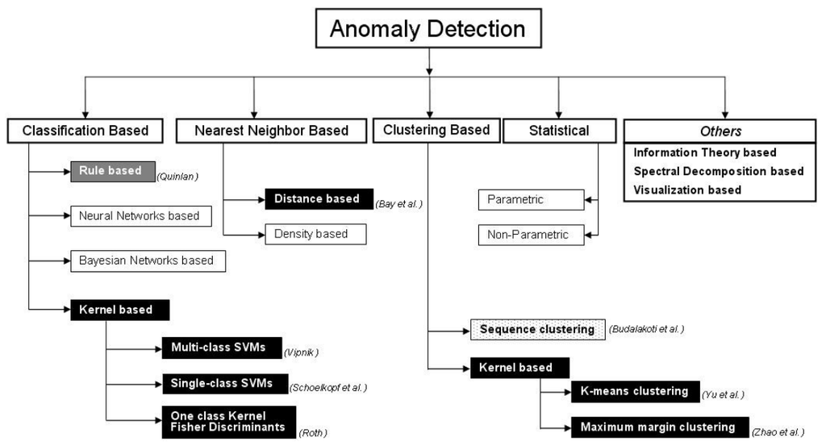

## 1.1 정규분포 단변량 - Grubbs 검정

1950년 Frank E. Grubbs은 정규분포를 따르는 모집단에 이상점을 판정하는 통계검정을 제안하였다.

$$G = \frac{\displaystyle\max_{i=1,\ldots, N}\left \vert Y_i - \bar{Y}\right\vert}{s}$$
$\overline{Y}$는 표본평균, $s$는 표준편차를 나타낸다. $N-2$를 따르는 $t-$분포의 임계점을 기준으로 이상점 여부를 판정한다.

Tietjen and Moore [^2] 논문에 제시된 데이터를 바탕으로 Grubbs 검정을 수행해본다. 분광계(spectrometer)에서 나온 측정치의 이상점을 탐지하게 된다.

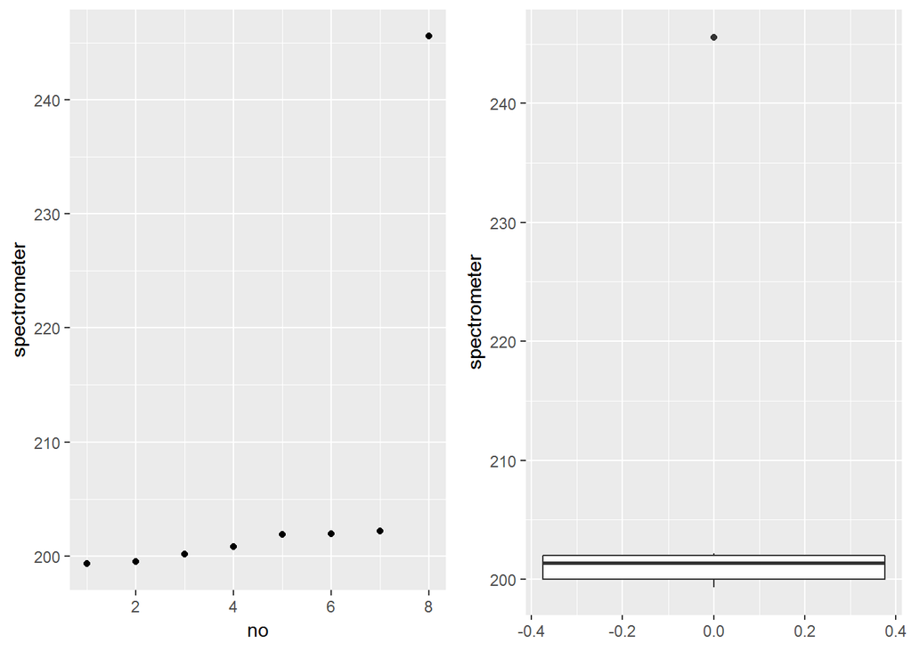

```r
library(tidyverse)
spectrometer <- c(199.31, 199.53, 200.19, 200.82, 201.92, 201.95, 202.18, 245.57)

spec_df <- tibble(
  no = seq(1:length(spectrometer)),
  spectrometer = spectrometer
)

point_g <- spec_df %>%
  ggplot(aes(x=no, y=spectrometer)) +
    geom_point()

boxplot_g <- spec_df %>%
  ggplot(aes(y=spectrometer)) +
    geom_boxplot()

cowplot::plot_grid(point_g, boxplot_g)
```

`outliers` 팩키지 `grubbs.test()` 함수를 통해서 정규분포 모집단을 가정하고 나온 단변량 변수로부터 이상점을 탐지해낼 수 있다.

```r
library(outliers)
grubbs.test(spectrometer, type = 10, opposite = FALSE, two.sided = FALSE)
```

```
    Grubbs test for one outlier

data:  spectrometer
G = 2.4688000, U = 0.0049308, p-value = 1.501e-07
alternative hypothesis: highest value 245.57 is an outlier
```

## 1.2 단변량 시계열 - Seasonal-Hybrid ESD [^3]

`wikipediatrend` 팩키지를 통해 위키백과사전 추세(trend) 데이터를 가져온다. 트위터 `AnomalyDetection` 팩키지의 `AnomalyDetectionVec()` 함수로 이상점을 검출하고 시각화한다.

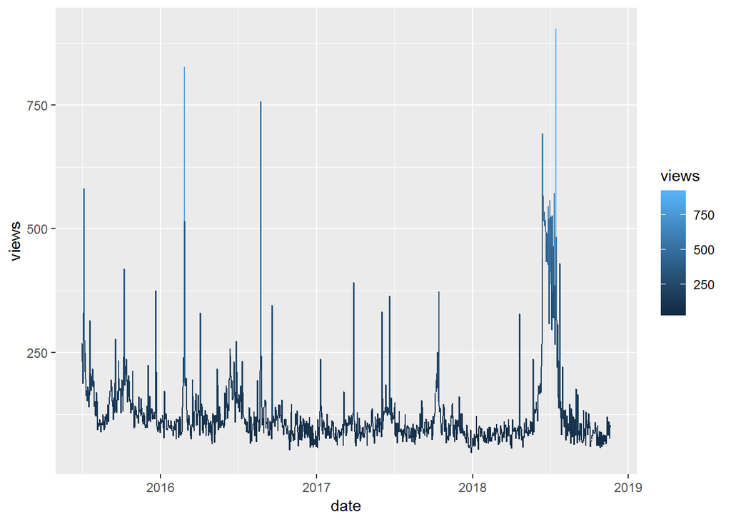

```r
library(AnomalyDetection)
library(wikipediatrend)

fifa_data_wikipedia  <- wp_trend("fifa", from="2013-03-18", lang = "en")

fifa_data_wikipedia %>%
  ggplot(aes(x=date, y=views, color=views)) +
  geom_line()
```

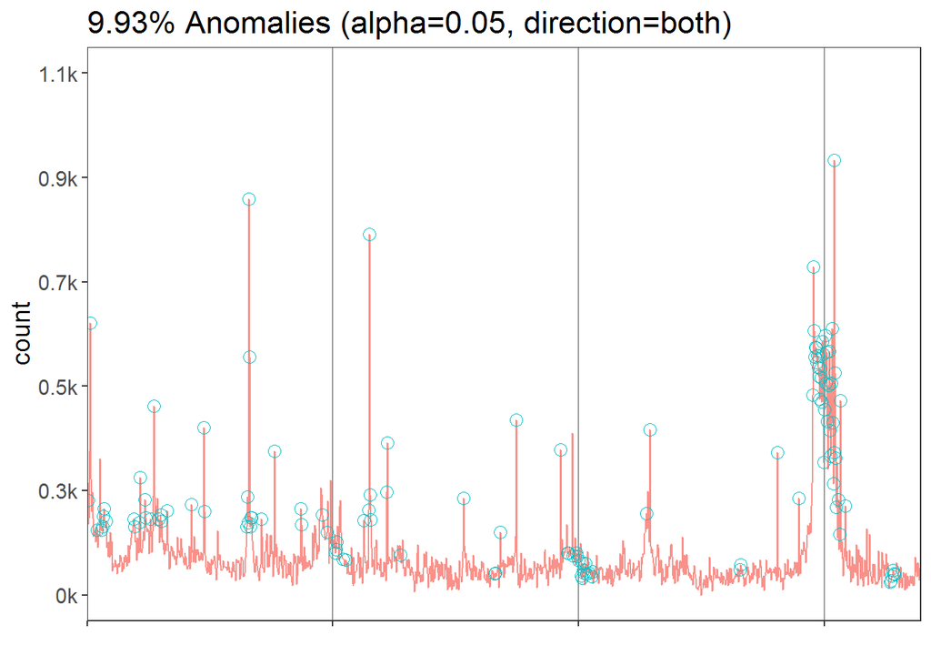

```r
anomalies <- AnomalyDetectionVec(fifa_data_wikipedia$views,
                                 direction="both", plot=TRUE,
                                 period = 365)
anomalies$plot
```

```r
anomalies$anoms %>%
  tbl_df() %>%
  DT::datatable()
```

|  | index | anoms |
| --- | --- | --- |
| 1 | 2 | 233 |
| 2 | 6 | 582 |
| 3 | 16 | 175 |
| 4 | 22 | 175 |
| 5 | 24 | 182 |
| 6 | 25 | 202 |
| 7 | 26 | 217 |
| 8 | 29 | 193 |
| 9 | 70 | 196 |
| 10 | 71 | 182 |

[output cut: 113 more lines]

# 2 다변량 전역/로컬 이상점

단변량이 아닌 다변량을 동원하여 **이상점(anomaly)**을 식별하는데 다차원 공간에서 전역 이상점을 식별하는 경우와 로컬 이상점을 식별하는 경우로 나눠진다.

## 2.1 다변량 전역 이상점

[FNN: Fast Nearest Neighbor Search Algorithms and Applications](https://cran.r-project.org/web/packages/FNN/index.html)

다변량 전역 이상점 탐지를 위해서 [Koncar, Philipp(February 11, 2018), “Dataset Open Access Synthetic Dataset for Outlier Detection”](https://zenodo.org/record/1171077#.W_UHTjgzZhE) 데이터를 예제로 삼아 분석을 시작해 나가자.

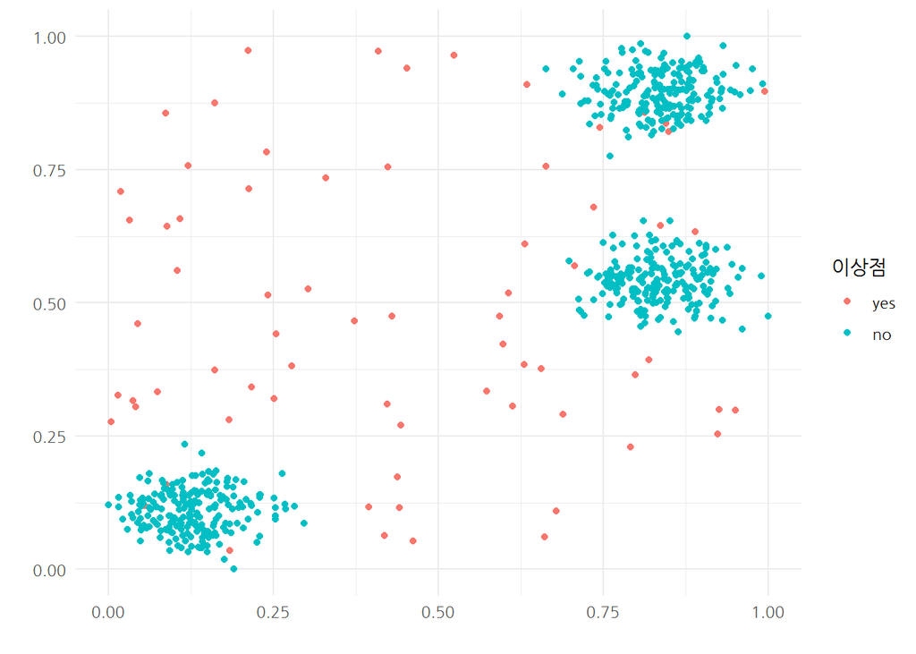

```r
library(FNN)
library(extrafont)
loadfonts()

outlier_dat <- read_csv("data/synthetic/synthetic_train_3.csv")

outlier_df <- outlier_dat %>%
  select(x=`4`, y=`5`, outlier) %>%
  mutate(outlier = factor(outlier, levels = c("yes", "no")))

outlier_df %>%
  ggplot(aes(x=x, y=y, color=outlier)) +
    geom_point() +
    labs(x="", y="", color="이상점") +
    theme_minimal(base_family = "NanumGothic")
```

### 2.1.1 `knn` 알고리즘

`FNN` 팩키지 `get.knn()` 함수를 활용해서 기본디폴트 설정된 인접 10 관측점을 대상으로 `knn` 알고리즘을 적용한다. `names(outlier_knn)` 명령어를 실행하게 되면 `nn.index`, `nn.dist`이 `outlier_knn` 객체에 저정된다. 이를 통해서 `knn_score` 및 해당 인덱스를 추출할 수 있게 된다.

```r
outlier_knn <- get.knn(data = outlier_df[,-3], k = 10)

names(outlier_knn)
```

```
[1] "nn.index" "nn.dist"
```

```r
outlier_df$knn_score <- rowMeans(outlier_knn$nn.dist)

DT::datatable(outlier_df)
```

|  | x | y | outlier | knn_score |
| --- | --- | --- | --- | --- |
| 1 | 0.0868818543932105 | 0.856331849523303 | yes | 0.176720950522844 |
| 2 | 0.523658485459982 | 0.964552727128253 | yes | 0.163005360501494 |
| 3 | 0.120431645956414 | 0.756916961796589 | yes | 0.132531514663607 |
| 4 | 0.250807832908946 | 0.320194194136089 | yes | 0.118725457076094 |
| 5 | 0.0411154001395566 | 0.304813489008399 | yes | 0.0911449333344504 |
| 6 | 0.950151638984867 | 0.298551453328366 | yes | 0.142972205055149 |
| 7 | 0.593115939416048 | 0.474137733399924 | yes | 0.108866631297059 |
| 8 | 0.0370157214335849 | 0.316846734012721 | yes | 0.0953345482480955 |
| 9 | 0.0321481234943465 | 0.654701780833924 | yes | 0.15315387911046 |
| 10 | 0.0881002397842844 | 0.158649578075798 | yes | 0.0128714041814436 |

[output cut: 690 more lines]

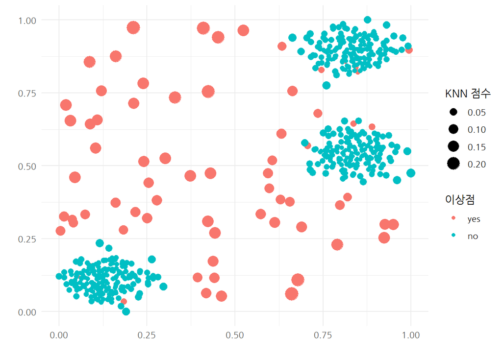

```r
outlier_df %>%
  ggplot(aes(x=x, y=y, color=outlier)) +
    geom_point(aes(size=knn_score)) +
    labs(x="", y="", color="이상점", size="KNN 점수") +
    theme_minimal(base_family = "NanumGothic")
```

```r
outlier_df[which.max(rowMeans(outlier_knn$nn.dist)), ]
```

```
# A tibble: 1 x 4
      x     y outlier knn_score
  <dbl> <dbl> <fct>       <dbl>
1 0.211 0.974 yes         0.229
```

`which.max(rowMeans(outlier_knn$nn.dist))` 명령어를 통해서 `knn_score`가 가장 높은 이상점을 인덱스를 뽑아낼 수도 있다.

## 2.2 다변량 지역 이상점

`knn` 알고리즘은 전역(Global) 이상점을 탐지하는데 반면에 `dbscan` 팩키지 `lof()` 함수는 지역(local) 이상점 검출에 도움을 줄 수 있다.

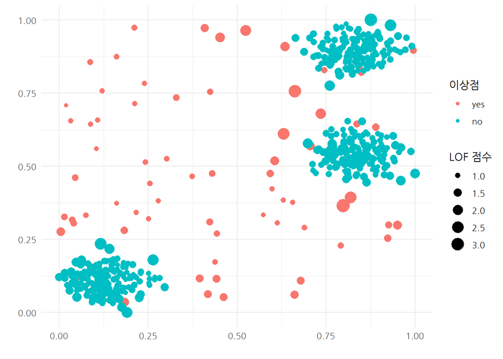

```r
library(dbscan)
outlier_df$lof_score <- lof(scale(outlier_df[,-c(3,4)]), k = 5)

outlier_df <- outlier_df %>%
  mutate(lof_outlier = ifelse(lof_score > 1, "yes", "no"))

outlier_df %>%
  ggplot(aes(x=x, y=y, color=outlier)) +
    geom_point(aes(size=lof_score)) +
    labs(x="", y="", color="이상점", size="LOF 점수") +
    theme_minimal(base_family = "NanumGothic")
```

# 3 `random forest` 모형 [^4]

`random forest` 모형을 활용하여 이상점을 검출하는 것도 가능하다. Isolation Forest는 비지도 어나멀리 검출 알고리즘으로 이상점(Anomaly)는 상대적으로 의사결정나무 분기가 적게 된다는 아이디어에 기초한 모형이다.

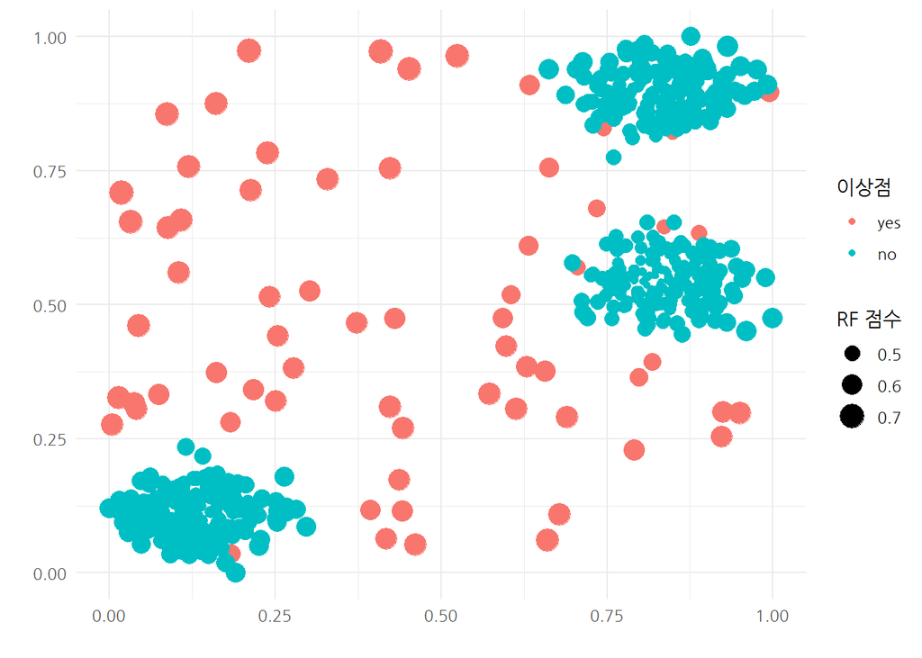

```r
library(isofor) # devtools::install_github("Zelazny7/isofor")

outlier_rf  <- iForest(X = outlier_df[,-c(3,4,5,6)], nt=100, phi=100, multicore = TRUE)

outlier_df$rf_score <-  predict(outlier_rf, newdata=outlier_df[,-c(3,4,5,6)])

outlier_df %>%
  ggplot(aes(x=x, y=y, color=outlier)) +
    geom_point(aes(size=rf_score)) +
    labs(x="", y="", color="이상점", size="RF 점수") +
    theme_minimal(base_family = "NanumGothic")
```

```r
outlier_df %>%
  DT::datatable()
```

|  | x | y | outlier | knn_score | lof_score | lof_outlier | rf_score |
| --- | --- | --- | --- | --- | --- | --- | --- |
| 1 | 0.0868818543932105 | 0.856331849523303 | yes | 0.176720950522844 | 1.07196205025241 | yes | 0.688312800095348 |
| 2 | 0.523658485459982 | 0.964552727128253 | yes | 0.163005360501494 | 2.29141402654593 | yes | 0.687206863183749 |
| 3 | 0.120431645956414 | 0.756916961796589 | yes | 0.132531514663607 | 1.00352409763794 | yes | 0.667731453448529 |
| 4 | 0.250807832908946 | 0.320194194136089 | yes | 0.118725457076094 | 1.00157046014372 | yes | 0.619896048012872 |
| 5 | 0.0411154001395566 | 0.304813489008399 | yes | 0.0911449333344504 | 1.17807734966086 | yes | 0.62948262562454 |
| 6 | 0.950151638984867 | 0.298551453328366 | yes | 0.142972205055149 | 1.66632240793266 | yes | 0.646760100591002 |
| 7 | 0.593115939416048 | 0.474137733399924 | yes | 0.108866631297059 | 1.36457811542198 | yes | 0.595226460409939 |
| 8 | 0.0370157214335849 | 0.316846734012721 | yes | 0.0953345482480955 | 1.17807734966086 | yes | 0.638522770799555 |
| 9 | 0.0321481234943465 | 0.654701780833924 | yes | 0.15315387911046 | 0.984985528772546 | no | 0.681103485920502 |
| 10 | 0.0881002397842844 | 0.158649578075798 | yes | 0.0128714041814436 | 1.07537789544661 | yes | 0.491494170734134 |

[output cut: 690 more lines]

등고선(contour) 그래프를 통해서 Isolation Forest 모형 예측값과 결합하여 시각화도 가능하다.

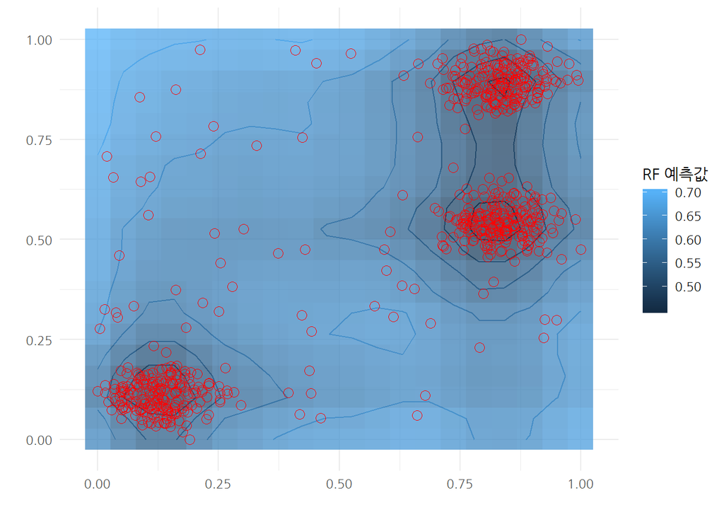

```r
x_seq <- seq(min(outlier_df$x), max(outlier_df$x), length.out = 20)
y_seq <- seq(min(outlier_df$y), max(outlier_df$y), length.out = 20)

outlier_grid_df <- expand.grid(x = x_seq, y = y_seq) %>%
  tbl_df()

outlier_grid_df$z <-  predict(outlier_rf, newdata=outlier_grid_df)

outlier_df$z <-  predict(outlier_rf, newdata=outlier_df[,-c(3,4,5,6)])

outlier_grid_df %>%
  ggplot(aes(x=x, y=y, fill=z)) +
    geom_contour(aes(z = z, colour = ..level..)) +
    geom_tile(aes(fill = z), alpha = 0.75) +
    labs(x="", y="", color="RF 예측값") +
    theme_minimal(base_family = "NanumGothic") +
     geom_point(data = outlier_df, aes(x = x, y = y), size = 3, shape = 1, color="red") +
     scale_fill_continuous(guide=FALSE)
```

# 4 범주형 변수 반영

범주형 변수를 반영하는 측도로 `Gower`를 활용하여 거리를 산출한 후에 `lof()` 함수에 넣어 이상점을 검출해내는 것도 가능하다.

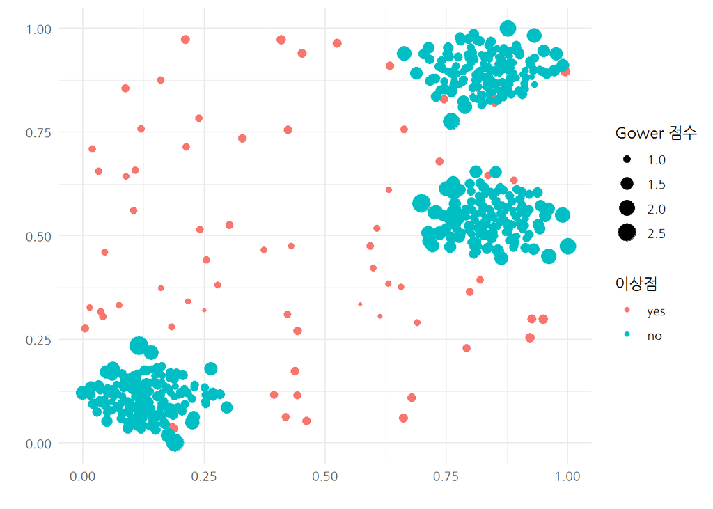

```r
outlier_m_df <- outlier_df %>%
  select(x, y, outlier)

library(cluster)
outlier_dist <- daisy(outlier_m_df, metric = "gower")

outlier_m_df$gower_score <- lof(outlier_dist, k = 10)

outlier_m_df %>%
  ggplot(aes(x=x, y=y, color=outlier)) +
    geom_point(aes(size=gower_score)) +
    labs(x="", y="", color="이상점", size="Gower 점수") +
    theme_minimal(base_family = "NanumGothic")
```

# 5 예측모형

`caret` 팩키지 프레임워크를 사용해서 Isolation Forest를 예측모형으로 적용할 경우 `Sensitivty(리콜)`이 상당히 높게 나오는 것을 확인할 수 있다.

```r
outlier_m_df <- outlier_df %>%
  select(x, y, outlier)

# 2. 예측모형 -----
## 2.1. 훈련/시험 데이터 분할 ------
library(caret)

xy_index <- createDataPartition(outlier_m_df$outlier, times =1, p=0.5, list=FALSE)

train_df <- outlier_m_df[xy_index, ]
test_df  <- outlier_m_df[-xy_index, ]

## 2.2. 모형 개발 ------

caret_rf <- iForest(outlier_m_df[, -3], nt = 100)

# 3. 예측모형 성능 -----
## Isolation Forest
rf_pred_df <- predict(caret_rf, newdata=test_df) %>%
  tbl_df %>%
  rename(score = value) %>%
  mutate(outlier = factor(ifelse( score > 0.5, "yes", "no"), levels = c("yes", "no")))

confusionMatrix(rf_pred_df$outlier, test_df$outlier, positive = "yes")
```

```
Confusion Matrix and Statistics

          Reference
Prediction yes  no
       yes  32  31
       no    3 284

               Accuracy : 0.9029
                 95% CI : (0.8669, 0.9318)
    No Information Rate : 0.9
    P-Value [Acc > NIR] : 0.4739

                  Kappa : 0.6019
 Mcnemar's Test P-Value : 3.649e-06

            Sensitivity : 0.91429
            Specificity : 0.90159
         Pos Pred Value : 0.50794
         Neg Pred Value : 0.98955
             Prevalence : 0.10000
         Detection Rate : 0.09143
   Detection Prevalence : 0.18000
      Balanced Accuracy : 0.90794

       'Positive' Class : yes
```

[^1]: [GRADIENT DESCENT(20 JUN 2017), “이상탐지 Anomaly Detection”](https://h3imdallr.github.io/2017-06-20/anomaly_detection/)
[^2]: Tietjen and Moore (August 1972), Some Grubbs-Type Statistics for the Detection of Outliers, Technometrics, 14(3), pp. 583-597.
[^3]: [R-posts.com, “Anomaly Detection in R - The World of Anomalies”](https://r-posts.com/anomaly-detection-in-r/)
[^4]: [Eryk Lewinson, “Outlier Detection with Isolation Forest”](https://towardsdatascience.com/outlier-detection-with-isolation-forest-3d190448d45e)